# 7. Pynar Editör Ayarları

## 7.1 Editör Yazı tipi değiştirme

**Örnek: Editör yazı tipini Arial yapmak**

Ayarlar sekmesi altındaki anahtar simgesine tıklayarak ayarlar penceresini açınız.

Editör yazı tipi ve boyutu satırındaki Değiştir yazısına tıklayınız.

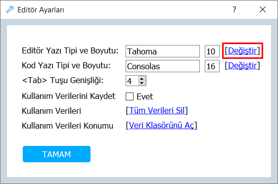

Yazı tipi başlığı altında Arial yazı tipini bulunuz. İsteğe bağlı olarak yazı tipi tarzını ve boyutunu değiştirebilirsiniz. Değişiklikleri yaptıktan sonra 'Tamam'a tıklayın.

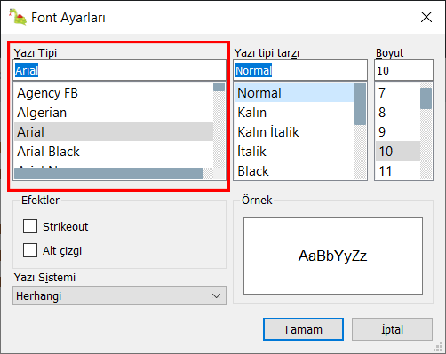

Editör Ayarları penceresinde yeniden 'Tamam'a tıklayın.

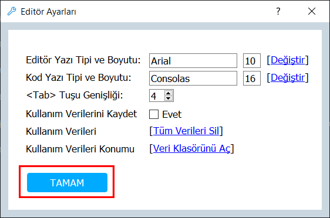

Değişiklikler Editör yeniden başlatıldığında aktif olacaktır.

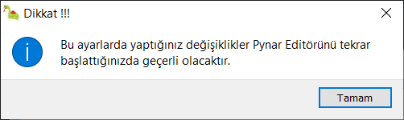

Editörü yeniden açtığınızda değişiklileri görebilirsiniz.

**Önce**

[figure not shown]

**Sonra**

[figure not shown]

## 7.2 Kod yazı tipi değiştirme

Ayarlar sekmesi altındaki anahtar simgesine tıklayarak ayarlar penceresini açınız.

Kod yazı tipi ve boyutu satırındaki Değiştir yazısına tıklayınız.

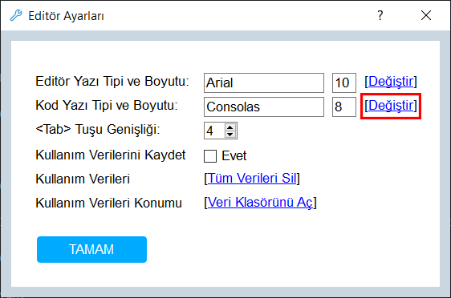

Yazı tipi başlığı altında Fixedsys yazı tipini bulunuz. İsteğe bağlı olarak yazı tipi tarzını ve boyutunu değiştirebilirsiniz. Değişiklikleri yaptıktan sonra 'Tamam'a tıklayın.

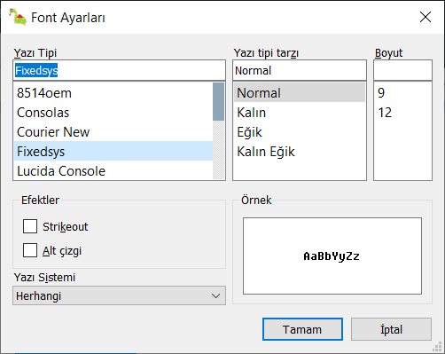

Editör Ayarları penceresinde yeniden 'Tamam'a tıklayın.

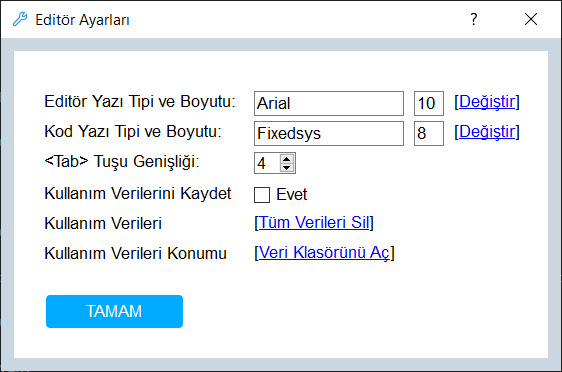

Değişiklikler Editör yeniden başlatıldığında aktif olacaktır.

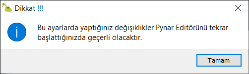

Editörü yeniden açtığınızda değişiklileri görebilirsiniz.

**Önce**

[figure not shown]

**Sonra**

[figure not shown]

## 7.3 Tab tuşu genişliği değiştirme

Ayarlar sekmesi altındaki anahtar simgesine tıklayarak ayarlar penceresini açınız.

<Tab> Tuşu Genişliğini istediğiniz gibi ayarlayınız.

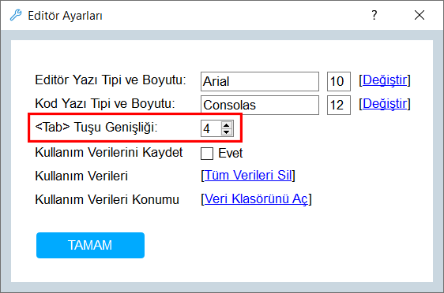

Değişikliği yaptıktan sonra 'Tamam'a tklayın.

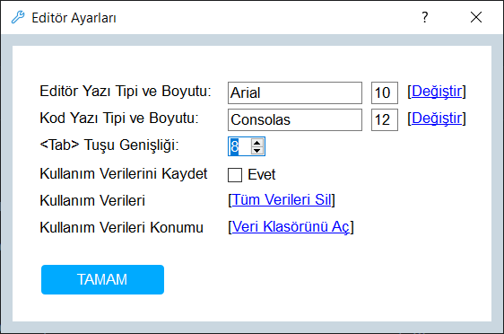

Editörü yeniden açtığınızda değişiklileri görebilirsiniz.

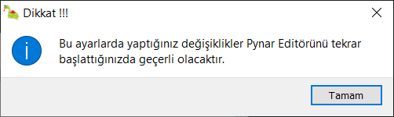

**Önce**

[figure not shown]

**Sonra**

[figure not shown]

Tab boşluğu arttırıldı.